# Chapter 13 in Class: Logistic Regression

## 1. Introduction to Logistic Regression

Logistic regression models a **binary outcome** (e.g., success/failure, yes/no) using the logistic function, which ensures probabilities are between 0 and 1.

### Why Not Use Linear Regression?

Linear regression can predict probabilities outside the valid range (0–1), which is meaningless for binary outcomes. Logistic regression uses a **logit transformation** to model probabilities.

### Real-Life Examples

1. Predicting whether a patient has a disease (1 = Yes, 0 = No).
2. Predicting whether an email is spam (1 = Spam, 0 = Not Spam).

## 2. Understanding Probabilities, Odds, and Log Odds

### Probability

The likelihood of success:
$$P(Y=1) = \frac{\text{Number of Successes}}{\text{Total Observations}}$$

### Odds

The ratio of success to failure:
$$\text{Odds} = \frac{P}{1-P}$$

### Log Odds

The natural log of odds:
$$\text{Log Odds} = \ln(\text{Odds})$$

## 3. The Logistic Function and Why We Exponentiate

The logistic function transforms log odds into probabilities:
$$P(Y=1) = \frac{e^{\beta_0 + \beta_1X}}{1 + e^{\beta_0 + \beta_1X}}$$

### Why Exponentiate Coefficients?

Logistic regression outputs coefficients in **log odds**, which are difficult to interpret. Exponentiating them converts log odds into **odds ratios**:
$$\text{Odds Ratio} = e^{\text{Log Odds}}$$

#### Example

If the coefficient for `GPA` is 1.5:
$$e^{1.5} \approx 4.48$$
This means a 1-unit increase in GPA multiplies the odds of success by 4.48.

## 4. Step-by-Step Guide to Running Logistic Regression (with `broom`)

### Why Use the `broom` Package?

The `broom` package simplifies the process of extracting, tidying, and visualizing regression output, making it easier to interpret results.

### Step 1: Simulate Data

```r
# Simulate Data
set.seed(123)
gpa <- runif(200, 2.5, 4.0)  # Predictor variable
admission <- rbinom(200, 1, prob = plogis(-2 + 0.8 * gpa))  # Moderate effect of GPA
dataset <- data.frame(admission, gpa)
```

### Step 2: Fit the Logistic Regression Model

```r
model <- glm(admission ~ gpa, data = dataset, family = "binomial")
```

### Step 3: Use `broom::tidy()` for Clean Output

```r
tidy_model <- tidy(model, exponentiate = TRUE, conf.int = TRUE)
tidy_model
```

```
## # A tibble: 2 × 7
##   term        estimate std.error statistic  p.value conf.low conf.high
##   <chr>          <dbl>     <dbl>     <dbl>    <dbl>    <dbl>     <dbl>
## 1 (Intercept)   0.0251     1.27      -2.91 0.00365   0.00196     0.288
## 2 gpa           3.88       0.395      3.43 0.000595  1.82        8.63
```

#### What Does `tidy(model, exponentiate = TRUE, conf.int = TRUE)` Do?

1. **`tidy()`**:
   - Extracts the model’s coefficients and organizes them into a tidy data frame.
   - Includes statistical estimates, standard errors, test statistics, and p-values.
2. **`exponentiate = TRUE`**:
   - Converts the coefficients from **log odds** to **odds ratios** by applying the exponential function:

   $$\text{Odds Ratio} = e^{\text{Log
   Odds}}$$
3. **`conf.int = TRUE`**:
   - Adds **confidence intervals** for the coefficients and exponentiates them to reflect odds ratios.

#### Interpreting the GPA Coefficient

- The **GPA coefficient** tells us how the odds of the outcome change for a **1-unit increase in GPA**.
  - **Estimate**: Odd Ratio=3.88:
    - For every 1-unit increase in GPA, the odds of admission increase by a factor of **3.88**.
  - **Confidence Interval (1.82 to 8.63)**:
    - With 95% confidence, the odds of admission for a 1-unit increase in GPA are between **1.82** and **8.63** times the baseline.
  - **p-value (<0.001)**:
    - The coefficient is statistically significant, meaning GPA is a strong predictor of admission.

#### How to Write These Results in Plain English

1. **Intercept**:
   - “When GPA is 0, the odds of admission are very low (odds ratio = 0.03).”
   - “With 95% confidence, the odds of admission at GPA = 0 are between 0.002 and 0.29.”
2. **GPA**:
   - “For every 1-point increase in GPA, the odds of admission increase by 3.88 times.”
   - “With 95% confidence, the odds of admission increase between 1.82 and 8.63 times for each additional point in GPA.”
   - “GPA is a statistically significant predictor of admission (p < 0.001).”

#### Odds Ratios vs. Probability

- Odds ratios tell us how much the odds of an outcome increase (or decrease) for a 1-unit change in the predictor.
- To calculate probabilities, you can use the logistic regression equation:

$$P(Y = 1) = \frac{e^{\beta_0 + \beta_1X}}{1 + e^{\beta_0 + \beta_1X}}$$

#### Key Points to Remember

1. **Exponentiating Coefficients**:
   - Transforms log odds into odds ratios, which are easier to interpret.
2. **Odds Ratio Interpretation**:
- $\text{Odds Ratio} > 1$: Increases odds of the outcome.
- $\text{Odds Ratio} < 1$: Decreases odds of the outcome.
- $\text{Odds Ratio} = 1$: No effect on the odds.
3. **Confidence Intervals**:
   - Provide a range of plausible values for the odds ratio.
4. **Statistical Significance**:
   - Determined by the ppp-value and whether the confidence interval excludes 1.

### Step 4: Predict Probabilities

```r
predict(model, newdata = data.frame(gpa = 3.5), type = "response")
```

```
##         1
## 0.7431673
```

This calculates the probability of admission for a GPA of 3.5.

## 5. Visualizing Logistic Regression

### DOT Plot for Odds Ratios

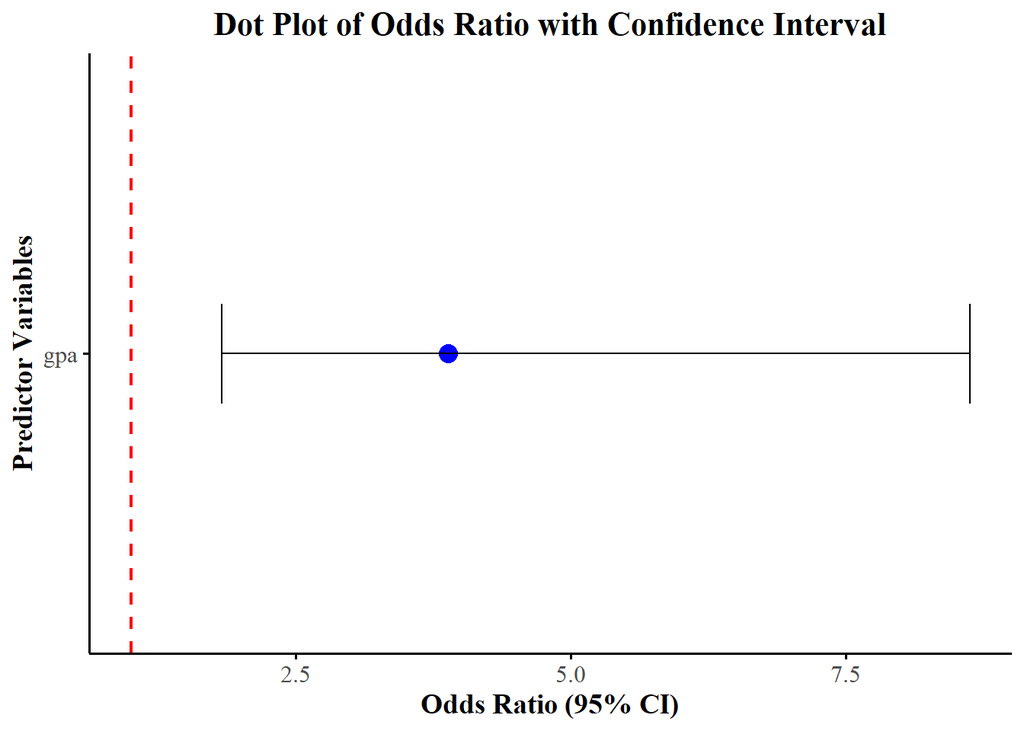

```r
# Extract Odds Ratios and Confidence Intervals, Exclude Intercept
tidy_plot <- tidy(model, conf.int = TRUE, exponentiate = TRUE) %>%
  filter(term != "(Intercept)")  # Exclude the intercept

# Create DOT Plot
ggplot(tidy_plot, aes(x = estimate, y = term)) +
  geom_point(size = 4, color = "blue") +  # Odds ratio point estimates
  geom_errorbar(aes(xmin = conf.low, xmax = conf.high), width = 0.2, color = "black") +  # Confidence intervals
  geom_vline(xintercept = 1, linetype = "dashed", color = "red", size = 0.8) +  # Reference line at OR = 1
  labs(title = "Dot Plot of Odds Ratio with Confidence Interval",
       x = "Odds Ratio (95% CI)",
       y = "Predictor Variables") +
  theme_apa()
```

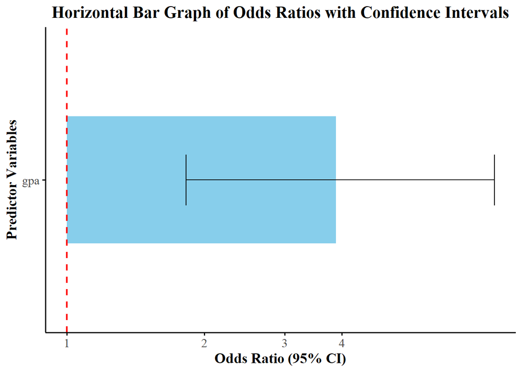

```r
# Create Horizontal Bar Graph
ggplot(tidy_plot, aes(y = term, x = estimate)) +
  geom_bar(stat = "identity", fill = "skyblue", width = 0.5) +  # Horizontal bars for odds ratios
  geom_errorbarh(aes(xmin = conf.low, xmax = conf.high), height = 0.2, color = "black") +  # Horizontal confidence intervals
  geom_vline(xintercept = 1, linetype = "dashed", color = "red", size = 0.8) +  # Reference line at OR = 1
  scale_x_log10(breaks = c(0.5, 1, 2, 3, 4)) +  # Logarithmic scale for odds ratios
  labs(title = "Horizontal Bar Graph of Odds Ratios with Confidence Intervals",
       x = "Odds Ratio (95% CI)",
       y = "Predictor Variables") +
  theme_apa()
```

## 6. Evaluating Model Fit with pROC and ROC Curve

### What is an ROC Curve?

- **Receiver Operating Characteristic (ROC) Curve**:
  - A graphical representation of a classifier’s performance at various threshold levels.
  - Plots the **True Positive Rate (TPR)** (Sensitivity) against the **False Positive Rate (FPR)** (1 - Specificity).
- **Area Under the Curve (AUC)**:
  - A single scalar value representing the overall performance of the classifier.
  - Ranges between 0 and 1:
    - AUC = 0.5: Model performs no better than random chance.
    - AUC = 1: Perfect classifier.

### Fit the Logistic Regression Model

### Calculate the ROC Curve and AUC

```r
# Load pROC Library
library(pROC)

# Predict Probabilities
predicted_probs <- predict(model, type = "response")

# Generate ROC Curve
roc_curve <- roc(dataset$admission, predicted_probs)

# Display AUC
auc_value <- auc(roc_curve)
print(paste("AUC:", round(auc_value, 3)))
```

```
## [1] "AUC: 0.65"
```

### Plot the ROC Curve

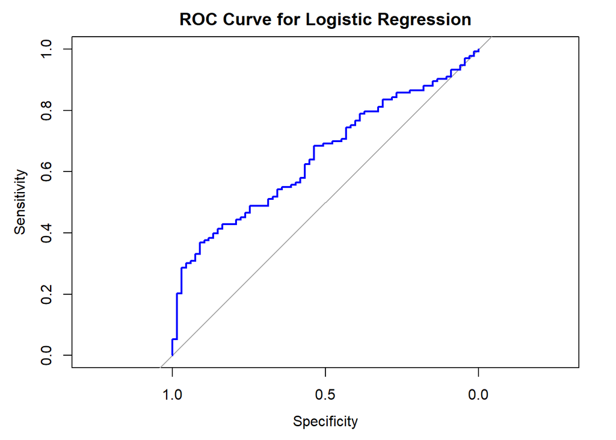

```r
# Plot the ROC Curve
plot(roc_curve, col = "blue", lwd = 2, main = "ROC Curve for Logistic Regression")
```

### Enhanced ROC Curve Visualization with ggplot2

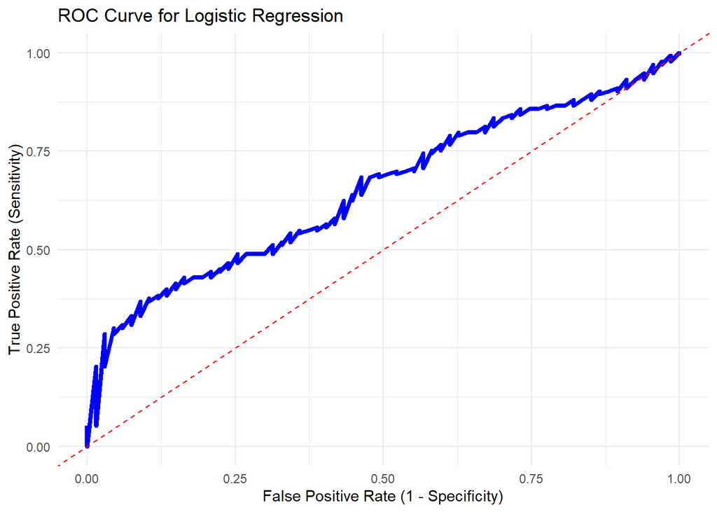

### Why Use the ROC Curve?

1. **Threshold Independence**:
   - The ROC curve evaluates performance across all possible classification thresholds.
2. **Robust Comparison**:
   - The AUC allows you to compare the performance of different logistic regression models.

## Additional Example: Logistic Regression with Two Predictors

### 1. Simulate Data with Two Predictors

```r
set.seed(456)
study_hours <- runif(200, 0, 10)  # Continuous predictor 1
sleep_hours <- runif(200, 4, 10)  # Continuous predictor 2
exam_pass <- rbinom(200, 1, prob = plogis(-3 + 0.8 * study_hours + 0.5 * sleep_hours))  # Binary outcome
dataset_two <- data.frame(exam_pass, study_hours, sleep_hours)

head(dataset_two)
```

```
##   exam_pass study_hours sleep_hours
## 1         1    0.895516    7.282157
## 2         1    2.105123    8.081090
## 3         1    7.329553    8.846939
## 4         1    8.521335    4.387895
## 5         1    7.883979    6.780246
## 6         1    3.319600    5.078511
```

### 2. Fit Logistic Regression Model with Two Predictors

```r
# Fit logistic regression mode
model_two <- glm(exam_pass ~ study_hours + sleep_hours, data = dataset_two, family = "binomial")

# Summarize the model
summary(model_two)
```

```
##
## Call:
## glm(formula = exam_pass ~ study_hours + sleep_hours, family = "binomial",
##     data = dataset_two)
##
## Coefficients:
##             Estimate Std. Error z value Pr(>|z|)
## (Intercept)  -3.8440     1.5600  -2.464 0.013739 *
## study_hours   1.0475     0.2903   3.608 0.000308 ***
## sleep_hours   0.5657     0.2269   2.493 0.012676 *
## ---
## Signif. codes:  0 '***' 0.001 '**' 0.01 '*' 0.05 '.' 0.1 ' ' 1
##
## (Dispersion parameter for binomial family taken to be 1)
##
##     Null deviance: 96.204  on 199  degrees of freedom
## Residual deviance: 54.411  on 197  degrees of freedom
## AIC: 60.411
##
## Number of Fisher Scoring iterations: 8
```

### 3. Interpret the Model Coefficients

```r
# Tidy the model output using broom
tidy_model_two <- tidy(model_two, conf.int = TRUE, exponentiate = TRUE)

# Display the tidy output
tidy_model_two
```

```
## # A tibble: 3 × 7
##   term        estimate std.error statistic  p.value conf.low conf.high
##   <chr>          <dbl>     <dbl>     <dbl>    <dbl>    <dbl>     <dbl>
## 1 (Intercept)   0.0214     1.56      -2.46 0.0137   0.000739     0.372
## 2 study_hours   2.85       0.290      3.61 0.000308 1.78         5.63
## 3 sleep_hours   1.76       0.227      2.49 0.0127   1.17         2.91
```

**Interpretation of Coefficients**: - **Intercept**: The baseline odds of passing when both `study_hours` and `sleep_hours` are 0. - **Study Hours**: The odds ratio shows how each additional hour of study affects the odds of passing. - **Sleep Hours**: The odds ratio shows how each additional hour of sleep affects the odds of passing.

### 4. Dot Plot for Odds Ratios and Confidence Intervals

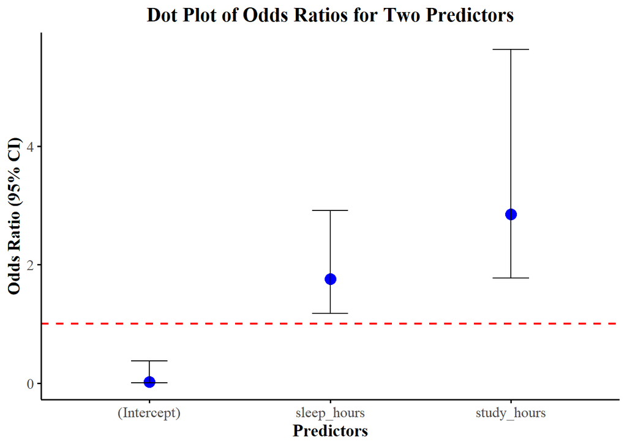

```r
# Create DOT Plot
ggplot(tidy_model_two, aes(x = term, y = estimate)) +
  geom_point(size = 4, color = "blue") +
  geom_errorbar(aes(ymin = conf.low, ymax = conf.high), width = 0.2, color = "black") +
  geom_hline(yintercept = 1, linetype = "dashed", color = "red", size = 0.8) +
  labs(
    title = "Dot Plot of Odds Ratios for Two Predictors",
    x = "Predictors",
    y = "Odds Ratio (95% CI)"
  ) +
  theme_apa()
```

### 5. Evaluate Model Fit with ROC Curve and AUC

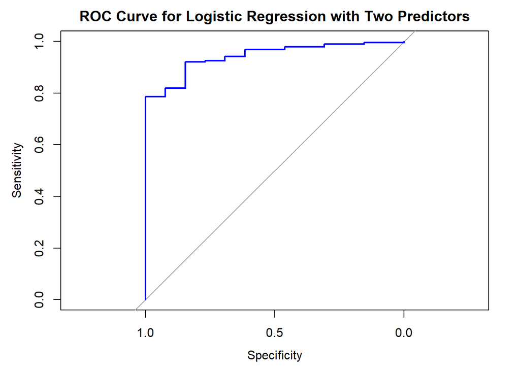

```r
# Predict probabilities
predicted_probs_two <- predict(model_two, type = "response")

# Generate ROC curve
roc_curve_two <- roc(dataset_two$exam_pass, predicted_probs_two)

# Plot ROC curve
plot(roc_curve_two, col = "blue", lwd = 2, main = "ROC Curve for Logistic Regression with Two Predictors")
```

```r
# Display AUC
auc_value_two <- auc(roc_curve_two)
print(paste("AUC:", round(auc_value_two, 3)))
```

```
## [1] "AUC: 0.942"
```

### 6. Enhanced ROC Curve Visualization with ggplot2

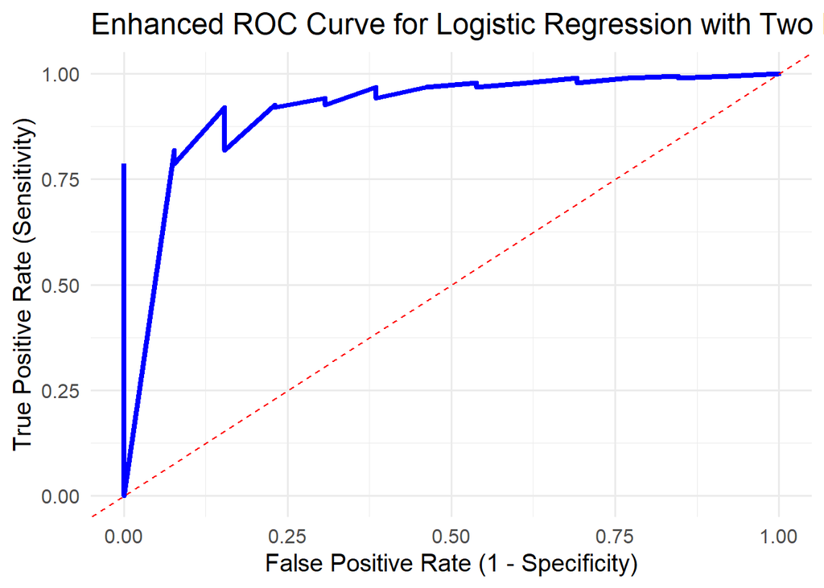

```r
# Convert ROC curve to data frame
roc_data_two <- data.frame(
  TPR = roc_curve_two$sensitivities,
  FPR = 1 - roc_curve_two$specificities
)

# Create ROC Curve Plot Using ggplot2
ggplot(roc_data_two, aes(x = FPR, y = TPR)) +
  geom_line(color = "blue", size = 1.5) +
  geom_abline(slope = 1, intercept = 0, linetype = "dashed", color = "red") +
  labs(
    title = "Enhanced ROC Curve for Logistic Regression with Two Predictors",
    x = "False Positive Rate (1 - Specificity)",
    y = "True Positive Rate (Sensitivity)"
  ) +
  theme_minimal(base_size = 15)
```

#### Key Insights from This Example

- **Study Hours**:
  - A statistically significant odds ratio indicates the positive effect of studying on passing the exam.
- **Sleep Hours**:
  - A significant odds ratio highlights the role of sleep in exam performance.
- **ROC Curve**:
  - The AUC quantifies the model’s ability to distinguish between pass/fail cases.